# Project Facebook Metrics

Sonali Sahu Patel || Viraj Parmar

2023-11-22

## Introduction

The project is focused on analyzing social media’s role in influencing customers by measuring the impact of status updates and advertisement on Facebook for a some cosmetic brand. The data used is from the UCI Machine Learning Repository. The response variable in the linear regression will be “Page Total Likes”. We are making the assumption that the total number of page likes is a good representation of brand reputation and social media engagement with consumers.

```r
FB_dataset1 <- read.csv("C:/Users/vinay/Sonali/Fall 2023 Courses/ITMD 514/HWGROUP28/Dataset Projects/facebook/dataset_Facebook.csv", header = TRUE, sep=";")
head(FB_dataset1)
```

```
  Page.total.likes   Type Category Post.Month Post.Weekday Post.Hour Paid
1           139441  Photo        2         12            4         3    0
2           139441 Status        2         12            3        10    0
3           139441  Photo        3         12            3         3    0
4           139441  Photo        2         12            2        10    1
5           139441  Photo        2         12            2         3    0
6           139441 Status        2         12            1         9    0
  Lifetime.Post.Total.Reach Lifetime.Post.Total.Impressions
1                      2752                            5091
2                     10460                           19057
3                      2413                            4373
4                     50128                           87991
5                      7244                           13594
6                     10472                           20849
  Lifetime.Engaged.Users Lifetime.Post.Consumers Lifetime.Post.Consumptions
```

[output cut: 34 more lines]

## Dataset Cleaning

```r
#Renaming the dataset for ease of use

FB_dataset2 <- data.frame(FB_dataset1)
names(FB_dataset2)[1] <- "Page.Total.Likes"
names(FB_dataset2)[2] <- "Type"
names(FB_dataset2)[3] <- "Category"
names(FB_dataset2)[4] <- "Post.Month"
names(FB_dataset2)[5] <- "Post.Weekday"
names(FB_dataset2)[6] <- "Post.Hour"
names(FB_dataset2)[7] <- "Paid"
names(FB_dataset2)[8] <- "Total.Reach"
names(FB_dataset2)[9] <- "Total.Impressions"
names(FB_dataset2)[10] <- "Engaged.Users"
names(FB_dataset2)[11] <- "Consumers"
names(FB_dataset2)[12] <- "Consumptions"
names(FB_dataset2)[13] <- "Impressions.for.Users.with.Likes"
names(FB_dataset2)[14] <- "Reach.by.Users.with.Likes"
names(FB_dataset2)[15] <- "Users.with.Likes.and.Engagement"
names(FB_dataset2)[16] <- "Comment"
names(FB_dataset2)[17] <- "Like"
names(FB_dataset2)[18] <- "Share"
names(FB_dataset2)[19] <- "Total.Interactions"

# Check for missing values
missing_values_present <- any(is.na(FB_dataset2))

print (missing_values_present)
```

```
[1] TRUE
```

```r
# Find which column has missing values
colSums(is.na(FB_dataset2))
```

```
                Page.Total.Likes                             Type
                               0                                0
                        Category                       Post.Month
                               0                                0
                    Post.Weekday                        Post.Hour
                               0                                0
                            Paid                      Total.Reach
                               1                                0
               Total.Impressions                    Engaged.Users
                               0                                0
                       Consumers                     Consumptions
                               0                                0
Impressions.for.Users.with.Likes        Reach.by.Users.with.Likes
                               0                                0
 Users.with.Likes.and.Engagement                          Comment
                               0                                0
                            Like                            Share
                               1                                4
              Total.Interactions
                               0
```

```r
# Find row indices with missing values
rows_with_missing <- which(apply(is.na(FB_dataset2), 1, any))

# Print the number of rows having missing values
print("Row numbers with missing values:")
```

```
[1] "Row numbers with missing values:"
```

```r
print(rows_with_missing)
```

```
[1] 112 121 125 165 500
```

Note- *Replacing missing values with 0 so that we can reduce the bias and sample size is maintained.* It would potentially increase the efficiency and also helps us to utilize the complete dataset.

```r
missing_values <- is.na(FB_dataset2)

# Eliminating N/A values with 0
FB_dataset2 [missing_values] <- 0
```

## Data Review

```r
# Count the number of observations (rows)
num_rows1 <- nrow(FB_dataset2)

print(paste("Number of rows in Dataset: ", num_rows1))
```

```
[1] "Number of rows in Dataset:  500"
```

```r
# Number of variables recorded
num_var <- ncol(FB_dataset2)

print(paste("Number of columns in Dataset: ", num_var))
```

```
[1] "Number of columns in Dataset:  19"
```

```r
# Types of random variables
str(FB_dataset2)
```

```
'data.frame':   500 obs. of  19 variables:
 $ Page.Total.Likes                : int  139441 139441 139441 139441 139441 139441 139441 139441 139441 139441 ...
 $ Type                            : chr  "Photo" "Status" "Photo" "Photo" ...
 $ Category                        : int  2 2 3 2 2 2 3 3 2 3 ...
 $ Post.Month                      : int  12 12 12 12 12 12 12 12 12 12 ...
 $ Post.Weekday                    : int  4 3 3 2 2 1 1 7 7 6 ...
 $ Post.Hour                       : int  3 10 3 10 3 9 3 9 3 10 ...
 $ Paid                            : num  0 0 0 1 0 0 1 1 0 0 ...
 $ Total.Reach                     : int  2752 10460 2413 50128 7244 10472 11692 13720 11844 4694 ...
 $ Total.Impressions               : int  5091 19057 4373 87991 13594 20849 19479 24137 22538 8668 ...
 $ Engaged.Users                   : int  178 1457 177 2211 671 1191 481 537 1530 280 ...
 $ Consumers                       : int  109 1361 113 790 410 1073 265 232 1407 183 ...
 $ Consumptions                    : int  159 1674 154 1119 580 1389 364 305 1692 250 ...
 $ Impressions.for.Users.with.Likes: int  3078 11710 2812 61027 6228 16034 15432 19728 15220 4309 ...
 $ Reach.by.Users.with.Likes       : int  1640 6112 1503 32048 3200 7852 9328 11056 7912 2324 ...
 $ Users.with.Likes.and.Engagement : int  119 1108 132 1386 396 1016 379 422 1250 199 ...
 $ Comment                         : int  4 5 0 58 19 1 3 0 0 3 ...
 $ Like                            : num  79 130 66 1572 325 ...
 $ Share                           : num  17 29 14 147 49 33 27 14 31 26 ...
 $ Total.Interactions              : int  100 164 80 1777 393 186 279 339 192 142 ...
```

- Here we observe that there are 500 rows and 19 variables.
- Variable 1 is response variable and variables from 2-7 are giving the information about the post.
- Variables from 8-19 (“Total.Reach”,“Total.Impressions”,“Engaged.Users”, etc.) are recorded after posting.
- They can give useful information about post reach, and we will be looking at them in EDA.

```r
#summary of the dataset
summary(FB_dataset2)
```

```
 Page.Total.Likes     Type              Category      Post.Month
 Min.   : 81370   Length:500         Min.   :1.00   Min.   : 1.000
 1st Qu.:112676   Class :character   1st Qu.:1.00   1st Qu.: 4.000
 Median :129600   Mode  :character   Median :2.00   Median : 7.000
 Mean   :123194                      Mean   :1.88   Mean   : 7.038
 3rd Qu.:136393                      3rd Qu.:3.00   3rd Qu.:10.000
 Max.   :139441                      Max.   :3.00   Max.   :12.000
  Post.Weekday    Post.Hour          Paid        Total.Reach
 Min.   :1.00   Min.   : 1.00   Min.   :0.000   Min.   :   238
 1st Qu.:2.00   1st Qu.: 3.00   1st Qu.:0.000   1st Qu.:  3315
 Median :4.00   Median : 9.00   Median :0.000   Median :  5281
 Mean   :4.15   Mean   : 7.84   Mean   :0.278   Mean   : 13903
 3rd Qu.:6.00   3rd Qu.:11.00   3rd Qu.:1.000   3rd Qu.: 13168
 Max.   :7.00   Max.   :23.00   Max.   :1.000   Max.   :180480
 Total.Impressions Engaged.Users       Consumers        Consumptions
 Min.   :    570   Min.   :    9.0   Min.   :    9.0   Min.   :    9.0
 1st Qu.:   5695   1st Qu.:  393.8   1st Qu.:  332.5   1st Qu.:  509.2
 Median :   9051   Median :  625.5   Median :  551.5   Median :  851.0
 Mean   :  29586   Mean   :  920.3   Mean   :  798.8   Mean   : 1415.1
 3rd Qu.:  22086   3rd Qu.: 1062.0   3rd Qu.:  955.5   3rd Qu.: 1463.0
 Max.   :1110282   Max.   :11452.0   Max.   :11328.0   Max.   :19779.0
 Impressions.for.Users.with.Likes Reach.by.Users.with.Likes
 Min.   :    567                  Min.   :  236
 1st Qu.:   3970                  1st Qu.: 2182
 Median :   6256                  Median : 3417
 Mean   :  16766                  Mean   : 6585
 3rd Qu.:  14860                  3rd Qu.: 7989
 Max.   :1107833                  Max.   :51456
 Users.with.Likes.and.Engagement    Comment             Like
 Min.   :   9.0                  Min.   :  0.000   Min.   :   0.0
 1st Qu.: 291.0                  1st Qu.:  1.000   1st Qu.:  56.0
 Median : 412.0                  Median :  3.000   Median : 101.0
 Mean   : 610.0                  Mean   :  7.482   Mean   : 177.6
 3rd Qu.: 656.2                  3rd Qu.:  7.000   3rd Qu.: 187.2
 Max.   :4376.0                  Max.   :372.000   Max.   :5172.0
     Share        Total.Interactions
 Min.   :  0.00   Min.   :   0.0
 1st Qu.: 10.00   1st Qu.:  71.0
 Median : 19.00   Median : 123.5
 Mean   : 27.05   Mean   : 212.1
 3rd Qu.: 32.00   3rd Qu.: 228.5
 Max.   :790.00   Max.   :6334.0
```

## Histogram of Page_Total_Likes

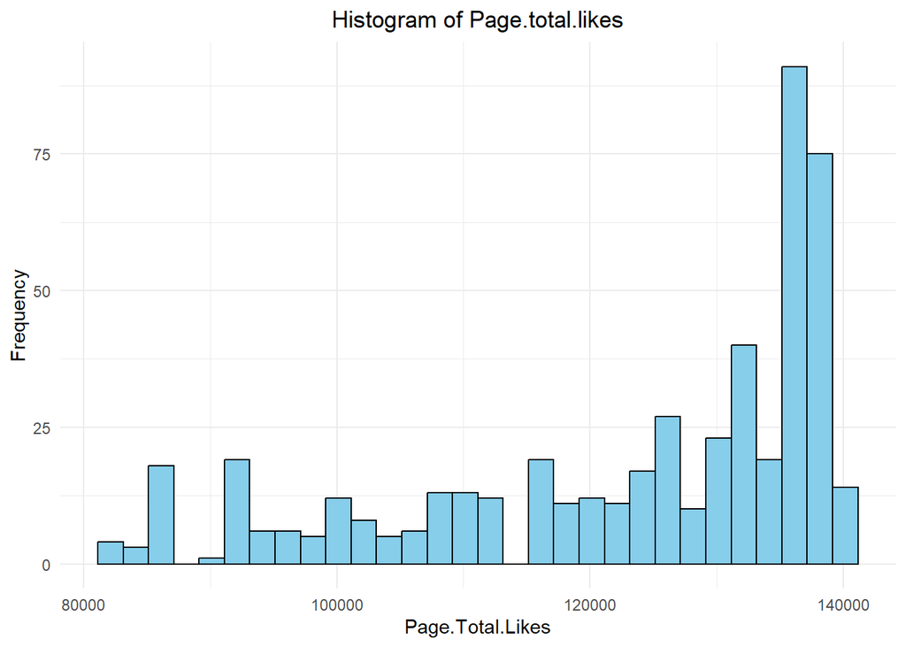

```r
#Histogram for Page_Total_Likes
ggplot(FB_dataset2, aes(x = Page.Total.Likes)) +
  geom_histogram(fill = "skyblue", color = "black", bins = 30) +
  labs(title = "Histogram of Page.total.likes",
       x = "Page.Total.Likes",
       y = "Frequency") +
  theme_minimal() +
  theme(plot.title = element_text(hjust = 0.5))
```

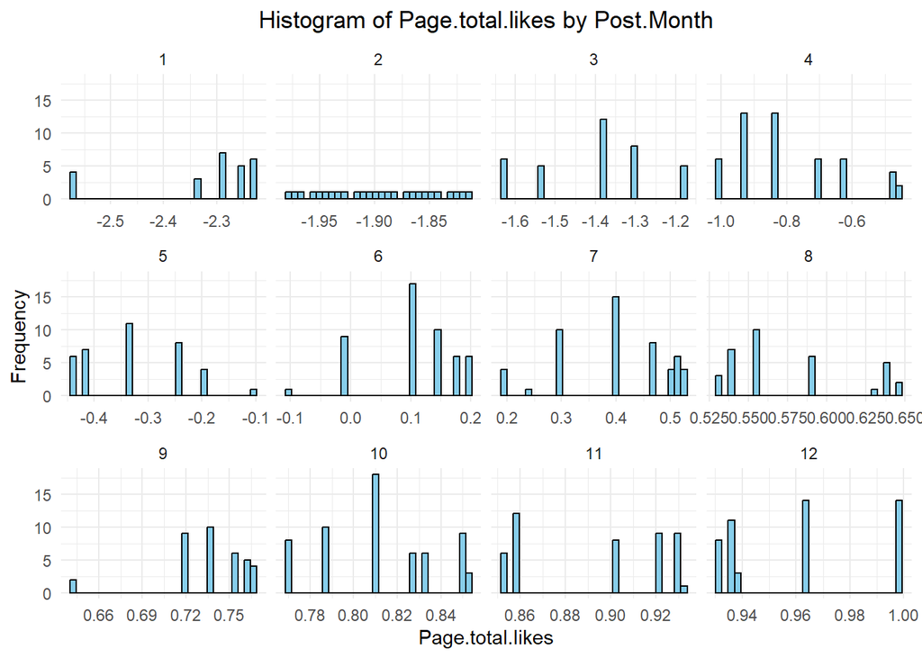

```r
 #standardizing Page_Total_Likes

Page.Total.Likes_z <- scale(FB_dataset2$Page.Total.Likes)


# Create a histogram for 'Page.total.likes' with facets for each month

ggplot(FB_dataset2, aes(x = Page.Total.Likes_z)) +
  geom_histogram(fill = "skyblue", color = "black", bins = 30) +
  facet_wrap(~Post.Month, scales = "free_x") +
  labs(title = "Histogram of Page.total.likes by Post.Month",
       x = "Page.total.likes",
       y = "Frequency") +
  theme_minimal() +
  theme(plot.title = element_text(hjust = 0.5))
```

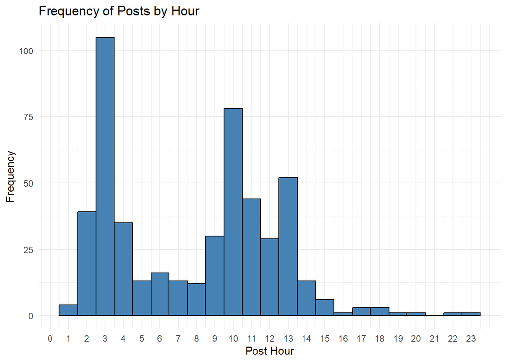

```r
# Histogram of Post.Hour
ggplot(data = FB_dataset2, aes(x = Post.Hour)) +
  geom_histogram(fill = "steelblue", binwidth = 1, color = "black") +
  labs(title = "Frequency of Posts by Hour", x = "Post Hour", y = "Frequency") +
  theme_minimal() +
  scale_x_continuous(breaks = 0:23)
```

- Here we observe that around post went live mostly at around 02:30 AM of the day.
- we can conclude that second spike at around 10:00 am.

## Boxplot of Post total reach by Type

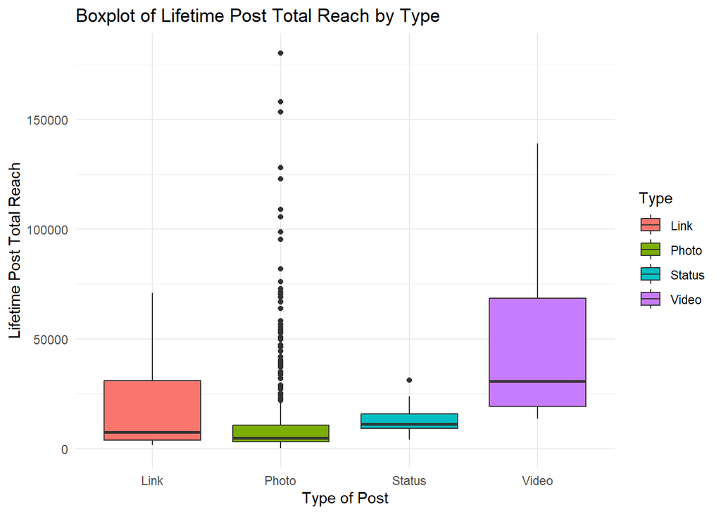

```r
ggplot(FB_dataset2, aes(x = Type, y = Total.Reach, fill = Type)) +
  geom_boxplot() +
  labs(title = "Boxplot of Lifetime Post Total Reach by Type",
       x = "Type of Post",
       y = "Lifetime Post Total Reach") +
  theme_minimal()
```

## Overlay histogram

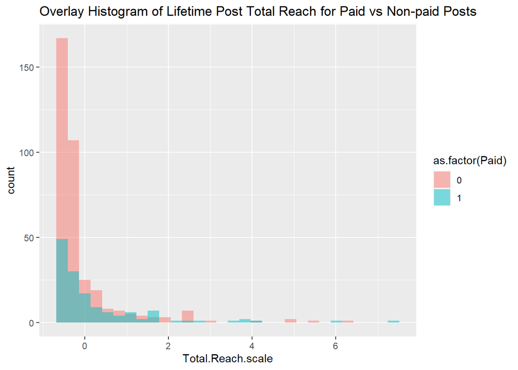

```r
Total.Reach.scale = scale(FB_dataset2$Total.Reach)
ggplot(FB_dataset2, aes(x=Total.Reach.scale, fill=as.factor(Paid))) +
  geom_histogram(position="identity", alpha=0.5, bins=30) +
  labs(title="Overlay Histogram of Lifetime Post Total Reach for Paid vs Non-paid Posts")
```

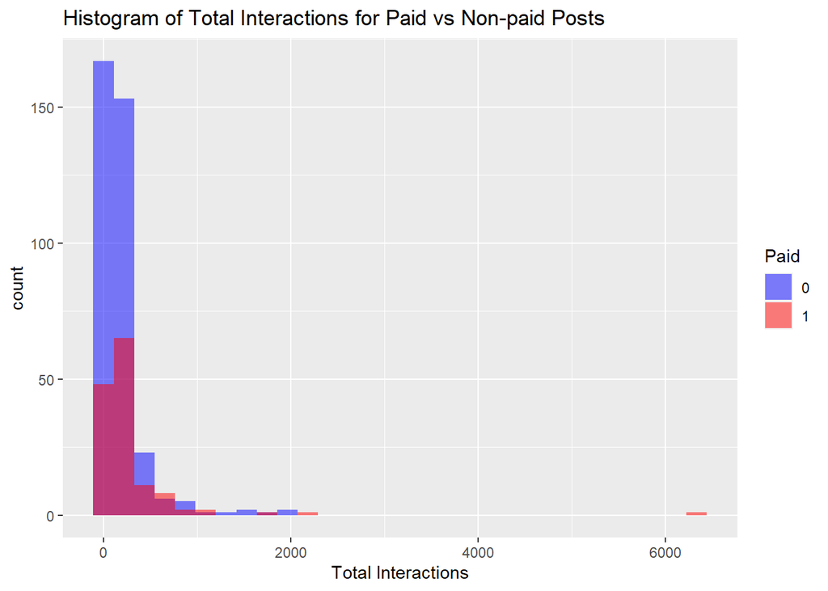

```r
# Overlay Histogram 'Total.Interactions' vs 'Paid'

ggplot(FB_dataset2, aes(x = Total.Interactions, fill = as.factor(Paid))) +
  geom_histogram(position = "identity", alpha = 0.5, bins = 30) +
  labs(title = "Histogram of Total Interactions for Paid vs Non-paid Posts",
       x = "Total Interactions") +
  scale_fill_manual(values = c("blue", "red"), name = "Paid")
```

## BarPLot based on the interactions vs category

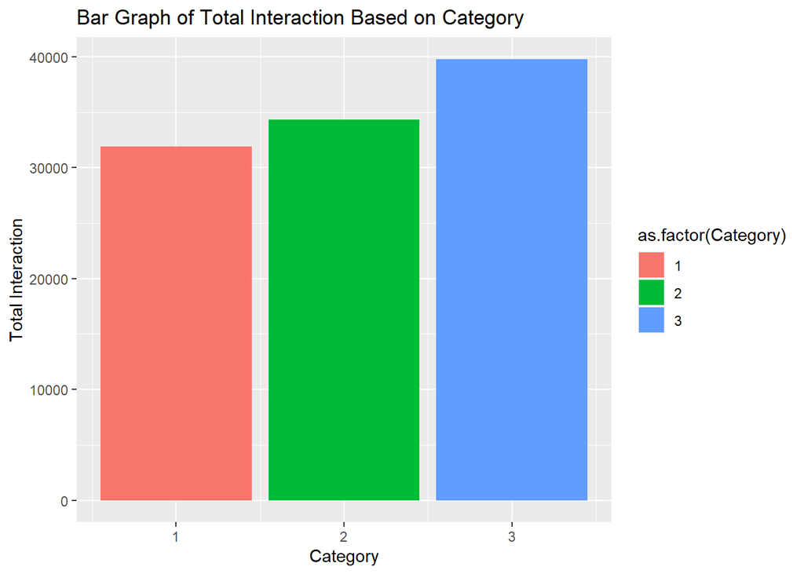

```r
ggplot(FB_dataset2, aes(x=Category, y=Total.Interactions, fill=as.factor(Category))) +
  geom_bar(stat="identity") +
  labs(title="Bar Graph of Total Interaction Based on Category") +
  xlab("Category") +
  ylab("Total Interaction")
```

- Here we have observed that the interactions (like, share & comment) with category 3 post is highest and category 1 post is lowest.

## Scatter Plot Total.Interactions vs Total.Reach

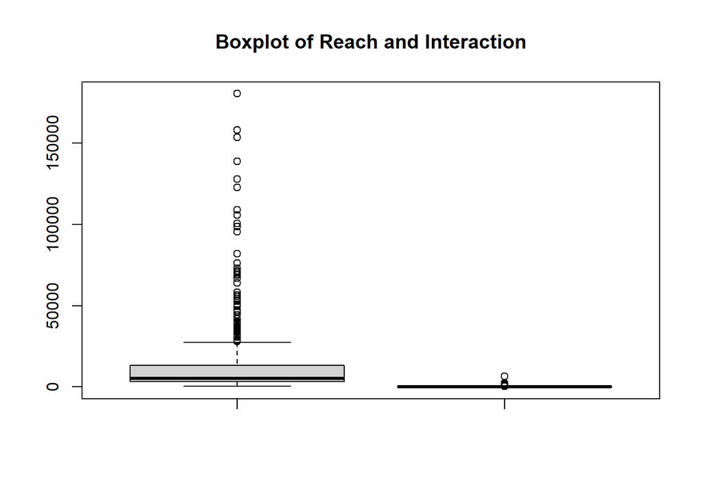

```r
# Create a boxplot to visualize outliers
boxplot(FB_dataset2$Total.Reach, FB_dataset2$Total.Interactions, main="Boxplot of Reach and Interaction")
```

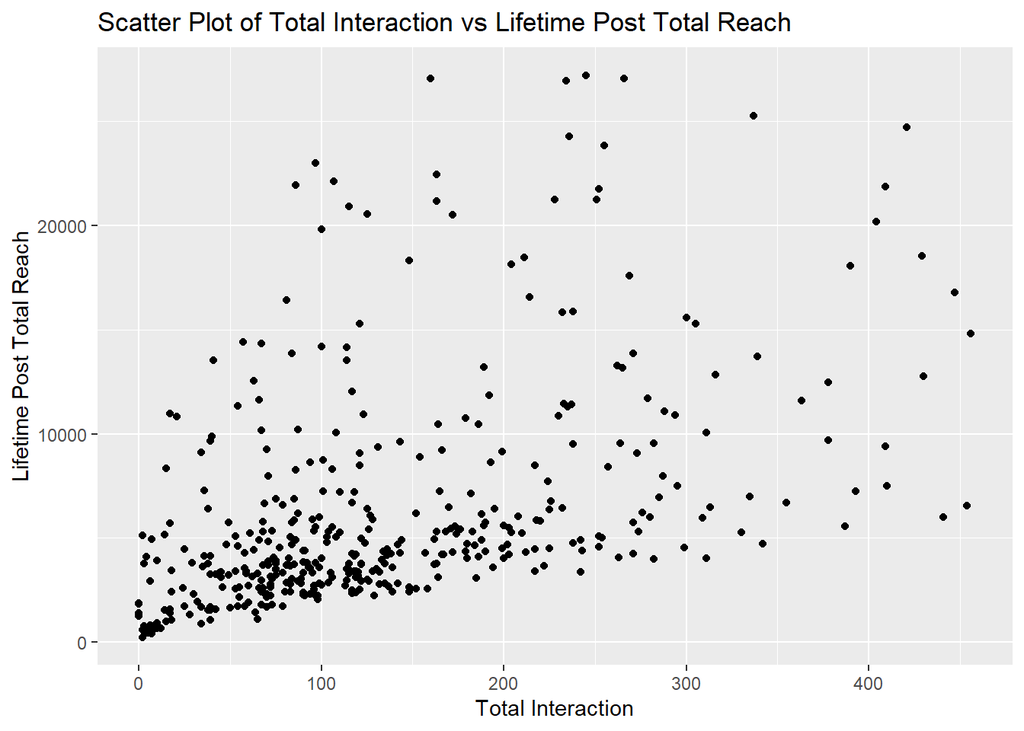

```r
# Identify and store outliers
outliers_reach <- boxplot.stats(FB_dataset2$Total.Reach)$out
outliers_interaction <- boxplot.stats(FB_dataset2$Total.Interactions)$out

# Remove outliers from the dataset
FB_dataset_no_outliers <- FB_dataset2[!(FB_dataset2$Total.Reach %in% outliers_reach), ]
FB_dataset_no_outliers <- FB_dataset_no_outliers[!(FB_dataset_no_outliers$Total.Interactions %in% outliers_interaction), ]

# Now FB_dataset_no_outliers contains the dataset with outliers removed

ggplot(FB_dataset_no_outliers, aes(x = Total.Interactions , y =  Total.Reach)) +
  geom_point() +
  labs(title = "Scatter Plot of Total Interaction vs Lifetime Post Total Reach") +
  xlab("Total Interaction") +
  ylab("Lifetime Post Total Reach")
```

## Hypothesis Testing

**Parameter:**

$\sigma^2_{NON} =$ variances of the interaction for non-paid post

$\sigma^2_{PAID} =$ variances of the interaction for paid post

- Here we will try to test variance for Total.Interactions of Paid and non-Paid post will be same.
- Assuming ‘Total.Interaction’ is the variable we want to test and ‘Paid’ is the grouping variable (1 for paid, 0 for non-paid)
- Assuming dataset follows normal Distribution

$$\begin{align*}
H_0: \sigma^2_{NON} = \sigma^2_{PAID} \\
H_1: \sigma^2_{NON} \ne \sigma^2_{PAID}
\end{align*}$$

```r
# Perform F-test for equality of variances
var_test_result <- var.test(Total.Interactions ~ Paid, data = FB_dataset2)

# Print the results
print(var_test_result)
```

```
    F test to compare two variances

data:  Total.Interactions by Paid
F = 0.17782, num df = 360, denom df = 138, p-value < 2.2e-16
alternative hypothesis: true ratio of variances is not equal to 1
95 percent confidence interval:
 0.1334348 0.2328657
sample estimates:
ratio of variances
         0.1778216
```

- Here we observe that the p-value is very small. So we infer that we reject the null hypothesis.
- Therefore, you have evidence to suggest that the variances of ‘Total.Interactions’ are not equal between paid and non-paid posts.
- The 95% confidence interval for the ratio of variances does not include 1, further supporting the conclusion that the variances are significantly different.

## T-Test

- Based on the result of F test, we conduct a hypothesis testing for the mean of `Total.Interactions` between `Paid`.

$$\begin{align*}
H_0: \mu_{NON} = \mu_{PAID}, \\
H_1: \mu_{NON} \ne \mu_{PAID}
\end{align*}$$

```r
t.test(Total.Interactions~Paid, data = FB_dataset2,var.equal = FALSE)
```

```
    Welch Two Sample t-test

data:  Total.Interactions by Paid
t = -1.7579, df = 157.26, p-value = 0.08071
alternative hypothesis: true difference in means between group 0 and group 1 is not equal to 0
95 percent confidence interval:
 -194.44675   11.31595
sample estimates:
mean in group 0 mean in group 1
       186.6648        278.2302
```

- Here the p-value is greater than alpha (0.05), so we fail to reject the null hypothesis.
- So there is not enough evidence to conclude that there is a significant difference in means between the two groups.

### Building linear Regression

```r
# Ignoring Few qualitative variables like type, category.
#  Also excluded variables comment, like , share as it is already considered in Total interactions.

FB_dataset <- FB_dataset2[, -c(2, 3,16,17,18 )]


#Dividing the dataset into two parts for training and testing
i <- sample(2, nrow(FB_dataset), replace=TRUE, prob=c(0.8, 0.2))
table(i)
```

```
i
  1   2
398 102
```

```r
FBTraining <- FB_dataset[i==1,]
FBTest <- FB_dataset[i==2,]



#  Simple Linear Regression for Page.Total.Likes on variable Post.Month
lm1 <- lm(Page.Total.Likes ~ Post.Month, data = FBTraining)

# Print the summary of the linear regression model
summary(lm1)
```

```
Call:
lm(formula = Page.Total.Likes ~ Post.Month, data = FBTraining)

Residuals:
     Min       1Q   Median       3Q      Max
-13567.9  -4506.5   -150.1   4646.8   8715.3

Coefficients:
            Estimate Std. Error t value Pr(>|t|)
(Intercept) 90245.49     646.15  139.67   <2e-16 ***
Post.Month   4692.46      84.14   55.77   <2e-16 ***
---
Signif. codes:  0 '***' 0.001 '**' 0.01 '*' 0.05 '.' 0.1 ' ' 1

Residual standard error: 5521 on 396 degrees of freedom
Multiple R-squared:  0.8871,    Adjusted R-squared:  0.8868
F-statistic:  3111 on 1 and 396 DF,  p-value: < 2.2e-16
```

Notes: -These statistics describe the distribution of the residuals (the differences between the observed and predicted values). -Intercept: The estimated intercept when ‘Post.Month’ is 0. Post.Month: The estimated change in ‘Page.Total.Likes’ for a one-unit change in ‘Post.Month.’ The model has very low p-value < 0.001). The Multiple R-squared value suggests that the model explains 88 percent of the variance in ‘Page.Total.Likes.’ The Adjusted R-squared considers the number of predictors and is close to the Multiple R-squared. The F-statistic is highly significant (p-value < 2e-16), indicating that the overall model is a good fit.

### Ploting the response and the predictor by Using the abline() function to display the least squares regression line.

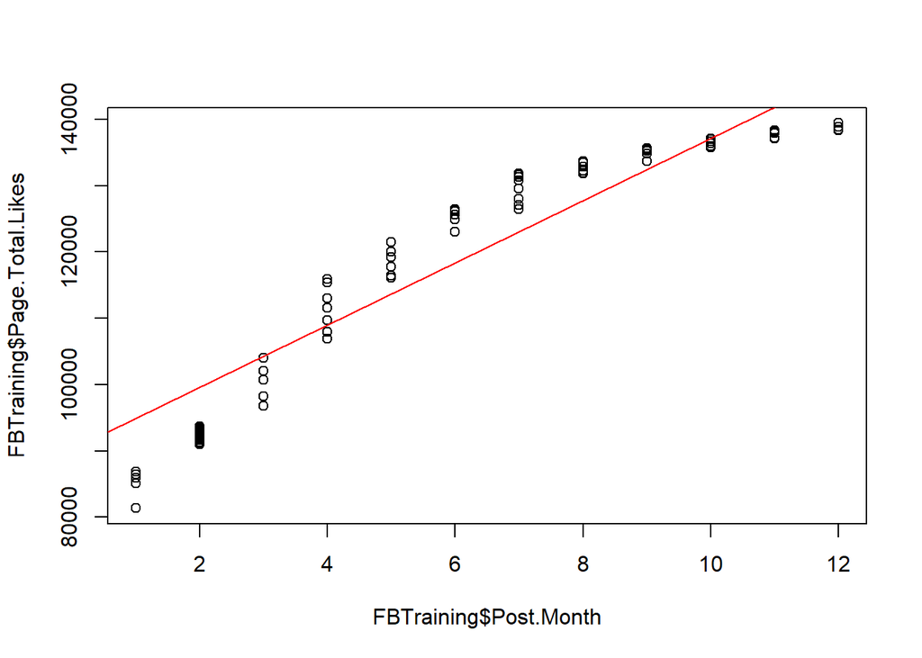

```r
plot(FBTraining$Post.Month,FBTraining$Page.Total.Likes)
abline(lm1,col="red")
```

* Here the red line is predicted value and is not very far away from the actual observations.

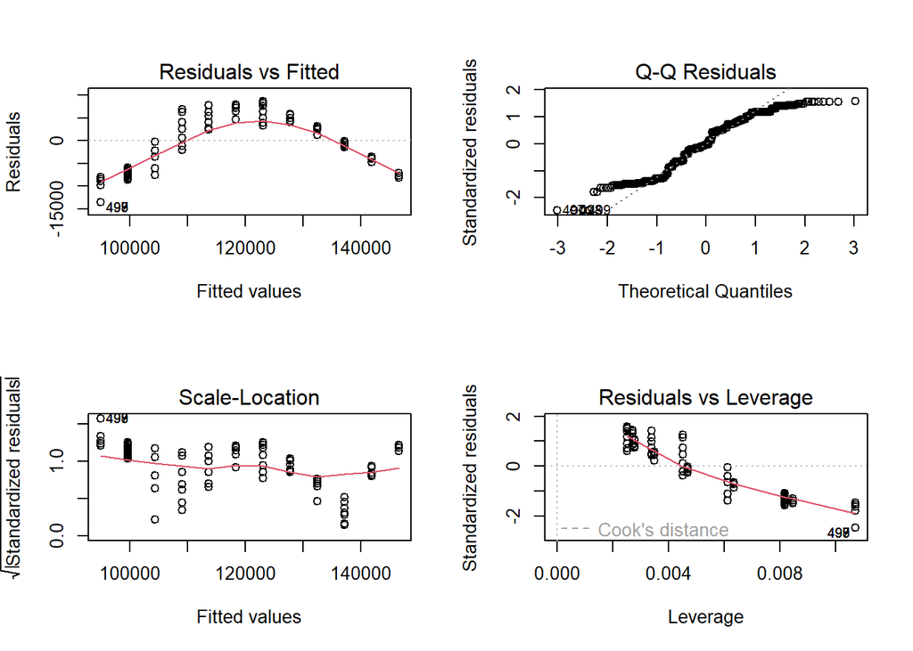

```r
par(mfrow=c(2,2))
plot(lm1)
```

- Here we observe that the residuals vs fitted plot shows that the relationship is non-linear.So we can consider that just taking the months are predictor is not the right approach.

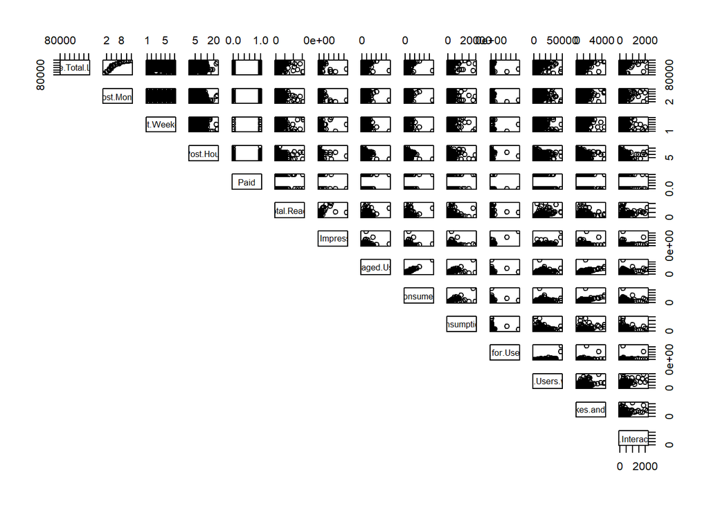

```r
pairs(FBTraining,lower.panel = NULL)
```

```r
# Finding the correlated matrix
cor_matrix <- cor(subset(FBTraining))
# Round the correlation matrix to 2 decimal places
rounded_cor_matrix <- round(cor_matrix, 2)

# Display the formatted matrix using print()
print(rounded_cor_matrix)
```

```
                                 Page.Total.Likes Post.Month Post.Weekday
Page.Total.Likes                             1.00       0.94         0.03
Post.Month                                   0.94       1.00         0.06
Post.Weekday                                 0.03       0.06         1.00
Post.Hour                                   -0.14      -0.17         0.05
Paid                                        -0.04      -0.08         0.01
Total.Reach                                 -0.12      -0.14        -0.08
Total.Impressions                           -0.12      -0.12        -0.05
Engaged.Users                               -0.13      -0.14        -0.08
Consumers                                   -0.16      -0.16        -0.07
Consumptions                                -0.14      -0.16        -0.04
Impressions.for.Users.with.Likes            -0.10      -0.10        -0.05
Reach.by.Users.with.Likes                   -0.07      -0.10        -0.09
Users.with.Likes.and.Engagement              0.03       0.00        -0.02
Total.Interactions                           0.05       0.03        -0.11
                                 Post.Hour  Paid Total.Reach Total.Impressions
Page.Total.Likes                     -0.14 -0.04       -0.12             -0.12
Post.Month                           -0.17 -0.08       -0.14             -0.12
Post.Weekday                          0.05  0.01       -0.08             -0.05
Post.Hour                             1.00 -0.08       -0.01              0.01
Paid                                 -0.08  1.00        0.10              0.02
Total.Reach                          -0.01  0.10        1.00              0.66
Total.Impressions                     0.01  0.02        0.66              1.00
Engaged.Users                        -0.01  0.12        0.53              0.33
Consumers                             0.00  0.11        0.47              0.29
Consumptions                          0.09  0.09        0.29              0.19
Impressions.for.Users.with.Likes      0.03 -0.02        0.30              0.86
Reach.by.Users.with.Likes             0.04  0.07        0.70              0.62
Users.with.Likes.and.Engagement       0.03  0.06        0.36              0.30
Total.Interactions                   -0.04  0.09        0.46              0.31
                                 Engaged.Users Consumers Consumptions
Page.Total.Likes                         -0.13     -0.16        -0.14
Post.Month                               -0.14     -0.16        -0.16
Post.Weekday                             -0.08     -0.07        -0.04
Post.Hour                                -0.01      0.00         0.09
Paid                                      0.12      0.11         0.09
Total.Reach                               0.53      0.47         0.29
Total.Impressions                         0.33      0.29         0.19
Engaged.Users                             1.00      0.98         0.67
Consumers                                 0.98      1.00         0.69
```

[output cut: 50 more lines]

```
                                 Total.Interactions
Page.Total.Likes                               0.05
Post.Month                                     0.03
Post.Weekday                                  -0.11
Post.Hour                                     -0.04
Paid                                           0.09
Total.Reach                                    0.46
Total.Impressions                              0.31
Engaged.Users                                  0.52
Consumers                                      0.36
Consumptions                                   0.23
Impressions.for.Users.with.Likes               0.28
Reach.by.Users.with.Likes                      0.65
Users.with.Likes.and.Engagement                0.54
Total.Interactions                             1.00
```

### Multiple linear Regression

```r
# Performing Multiple linear for the FBTraining dataset
lm2 <- lm(Page.Total.Likes~., data=FBTraining)
summary(lm2)
```

```
Call:
lm(formula = Page.Total.Likes ~ ., data = FBTraining)

Residuals:
     Min       1Q   Median       3Q      Max
-13152.2  -4105.9    459.5   4429.7   9642.9

Coefficients:
                                   Estimate Std. Error t value Pr(>|t|)
(Intercept)                       8.991e+04  1.144e+03  78.575   <2e-16 ***
Post.Month                        4.695e+03  9.127e+01  51.441   <2e-16 ***
Post.Weekday                     -2.700e+02  1.360e+02  -1.985   0.0479 *
Post.Hour                         8.173e+01  6.413e+01   1.274   0.2033
Paid                              1.393e+03  6.093e+02   2.286   0.0228 *
Total.Reach                       6.750e-02  5.322e-02   1.268   0.2054
Total.Impressions                -2.249e-02  1.806e-02  -1.245   0.2138
Engaged.Users                    -8.933e+00  5.832e+00  -1.532   0.1264
Consumers                         6.462e+00  5.790e+00   1.116   0.2650
Consumptions                      1.542e-01  1.781e-01   0.865   0.3873
Impressions.for.Users.with.Likes  1.441e-02  2.004e-02   0.719   0.4723
Reach.by.Users.with.Likes         1.218e-02  1.171e-01   0.104   0.9172
Users.with.Likes.and.Engagement   2.735e+00  1.115e+00   2.453   0.0146 *
Total.Interactions                4.681e+00  4.091e+00   1.144   0.2532
---
Signif. codes:  0 '***' 0.001 '**' 0.01 '*' 0.05 '.' 0.1 ' ' 1

Residual standard error: 5397 on 384 degrees of freedom
Multiple R-squared:  0.8954,    Adjusted R-squared:  0.8918
F-statistic: 252.7 on 13 and 384 DF,  p-value: < 2.2e-16
```

- Here we observe that there is strong relationship between the predictors variables like ‘Post.Month’ and ‘Users.with.Likes.and.Engagement’ on response ‘Page.Total.Likes’
- The F-statistic is highly significant (p-value < 2.2e-16), indicating that the overall model is a good fit.
- As the Multiple R-squared value is 89 % which explains that the variability in response can be explained by the predictors included in the model.

## Evaluating Model Accuracy

```r
# Predicting the Page.total.Likes

Page.Total.Likes_Predict = predict(lm2, FBTest)
FBTest$Page.Total.Likes_Predict = Page.Total.Likes_Predict
View(FBTest)

# Mean Absolute error
MAE(FBTest$Page.Total.Likes_Predict, FBTest$Page.Total.Likes)
```

```
[1] 4867.81
```

```r
# Mean squared error
MSE(FBTest$Page.Total.Likes_Predict, FBTest$Page.Total.Likes)
```

```
[1] 29963682
```

```r
# Mean Absolute Percentage Error
error = MAPE(FBTest$Page.Total.Likes_Predict, FBTest$Page.Total.Likes)
error
```

```
[1] 0.04004189
```

```r
#Accuracy

Accuracy= 1-error
Accuracy
```

```
[1] 0.9599581
```

- Here notice that the model has accuracy of about 0.9599581

### Backward Selection

```r
# Create a null model
intercept_only <- lm(Page.Total.Likes ~ 1, data = FBTraining)
# Create a full model
all <- lm(Page.Total.Likes~., data = FBTraining)
# performing Backward stepwise regression
backward <- stepAIC (all, direction='backward',trace = 0)
```

```r
backward$anova
```

```
Stepwise Model Path
Analysis of Deviance Table

Initial Model:
Page.Total.Likes ~ Post.Month + Post.Weekday + Post.Hour + Paid +
    Total.Reach + Total.Impressions + Engaged.Users + Consumers +
    Consumptions + Impressions.for.Users.with.Likes + Reach.by.Users.with.Likes +
    Users.with.Likes.and.Engagement + Total.Interactions

Final Model:
Page.Total.Likes ~ Post.Month + Post.Weekday + Paid + Total.Reach +
    Total.Impressions + Engaged.Users + Users.with.Likes.and.Engagement

                                Step Df   Deviance Resid. Df  Resid. Dev
1                                                        384 11186814402
2        - Reach.by.Users.with.Likes  1   315015.2       385 11187129417
3                     - Consumptions  1 21978608.3       386 11209108026
4 - Impressions.for.Users.with.Likes  1 39388475.6       387 11248496501
5                        - Consumers  1 28479453.3       388 11276975954
6               - Total.Interactions  1  5160186.7       389 11282136141
7                        - Post.Hour  1 54760851.8       390 11336896993
       AIC
1 6854.317
2 6852.328
3 6851.109
4 6850.505
5 6849.512
6 6847.694
7 6847.621
```

```r
summary(backward)
```

```
Call:
lm(formula = Page.Total.Likes ~ Post.Month + Post.Weekday + Paid +
    Total.Reach + Total.Impressions + Engaged.Users + Users.with.Likes.and.Engagement,
    data = FBTraining)

Residuals:
     Min       1Q   Median       3Q      Max
-13249.0  -4066.3    413.3   4434.4   9450.0

Coefficients:
                                  Estimate Std. Error t value Pr(>|t|)
(Intercept)                      9.113e+04  9.259e+02  98.424  < 2e-16 ***
Post.Month                       4.637e+03  8.523e+01  54.411  < 2e-16 ***
Post.Weekday                    -2.793e+02  1.344e+02  -2.078 0.038338 *
Paid                             1.304e+03  6.042e+02   2.157 0.031579 *
Total.Reach                      3.723e-02  1.942e-02   1.917 0.055997 .
Total.Impressions               -7.928e-03  4.554e-03  -1.741 0.082486 .
Engaged.Users                   -2.146e+00  5.587e-01  -3.841 0.000143 ***
Users.with.Likes.and.Engagement  3.291e+00  8.138e-01   4.043 6.35e-05 ***
---
Signif. codes:  0 '***' 0.001 '**' 0.01 '*' 0.05 '.' 0.1 ' ' 1

Residual standard error: 5392 on 390 degrees of freedom
Multiple R-squared:  0.8939,    Adjusted R-squared:  0.892
F-statistic: 469.6 on 7 and 390 DF,  p-value: < 2.2e-16
```

```r
# Predicting the Page.total.Likes

Page.Total.Likes_Predict <- predict(backward, FBTest)
FBTest$Page.Total.Likes_Predict <- Page.Total.Likes_Predict

# Mean Absolute error
MAE(FBTest$Page.Total.Likes_Predict, FBTest$Page.Total.Likes)
```

```
[1] 4889.242
```

```r
# Mean squared error
MSE(FBTest$Page.Total.Likes_Predict, FBTest$Page.Total.Likes)
```

```
[1] 30254830
```

```r
# Mean Absolute Percentage Error
error = MAPE(FBTest$Page.Total.Likes_Predict, FBTest$Page.Total.Likes)
error
```

```
[1] 0.04033422
```

```r
#Accuracy

Accuracy= 1-error
Accuracy
```

```
[1] 0.9596658
```

### Backward Selection with qualitative variable

```r
FB_dataset3 <- FB_dataset2[, -c(16,17,18 )]


#Dividing the dataset into two parts for training and testing
i <- sample(2, nrow(FB_dataset3), replace=TRUE, prob=c(0.8, 0.2))
FBTraining3 <- FB_dataset3[i==1,]
FBTest3 <- FB_dataset3[i==2,]


# Create a null model
intercept_only <- lm(Page.Total.Likes ~ 1, data = FBTraining3)
# Create a full model
all <- lm(Page.Total.Likes~., data = FBTraining3)
# performing Backward stepwise regression
backward2 <- stepAIC (all, direction='backward',trace = 0)
backward2$anova
```

```
Stepwise Model Path
Analysis of Deviance Table

Initial Model:
Page.Total.Likes ~ Type + Category + Post.Month + Post.Weekday +
    Post.Hour + Paid + Total.Reach + Total.Impressions + Engaged.Users +
    Consumers + Consumptions + Impressions.for.Users.with.Likes +
    Reach.by.Users.with.Likes + Users.with.Likes.and.Engagement +
    Total.Interactions

Final Model:
Page.Total.Likes ~ Type + Category + Post.Month + Post.Weekday +
    Paid + Total.Reach + Total.Impressions + Engaged.Users +
    Consumers + Impressions.for.Users.with.Likes + Users.with.Likes.and.Engagement +
    Total.Interactions

                         Step Df Deviance Resid. Df  Resid. Dev      AIC
1                                               399 11261477486 7171.524
2 - Reach.by.Users.with.Likes  1  3315676       400 11264793163 7169.646
3                 - Post.Hour  1  5338204       401 11270131366 7167.844
4              - Consumptions  1 22891913       402 11293023279 7166.690
```

```r
summary(backward2)
```

```
Call:
lm(formula = Page.Total.Likes ~ Type + Category + Post.Month +
    Post.Weekday + Paid + Total.Reach + Total.Impressions + Engaged.Users +
    Consumers + Impressions.for.Users.with.Likes + Users.with.Likes.and.Engagement +
    Total.Interactions, data = FBTraining3)

Residuals:
     Min       1Q   Median       3Q      Max
-14632.7  -3715.3    538.7   4399.3   8962.0

Coefficients:
                                   Estimate Std. Error t value Pr(>|t|)
(Intercept)                       8.537e+04  1.682e+03  50.745  < 2e-16 ***
TypePhoto                         5.154e+03  1.333e+03   3.868 0.000128 ***
TypeStatus                        4.786e+03  1.918e+03   2.496 0.012968 *
TypeVideo                         3.829e+03  2.627e+03   1.458 0.145676
Category                          5.344e+02  3.365e+02   1.588 0.113065
Post.Month                        4.594e+03  9.133e+01  50.304  < 2e-16 ***
Post.Weekday                     -1.890e+02  1.293e+02  -1.462 0.144565
Paid                              1.150e+03  5.912e+02   1.945 0.052419 .
Total.Reach                       1.051e-01  3.331e-02   3.155 0.001726 **
Total.Impressions                -3.557e-02  1.374e-02  -2.588 0.010001 *
Engaged.Users                    -1.389e+01  6.199e+00  -2.241 0.025577 *
Consumers                         1.157e+01  6.086e+00   1.901 0.058028 .
Impressions.for.Users.with.Likes  2.576e-02  1.351e-02   1.907 0.057281 .
Users.with.Likes.and.Engagement   2.483e+00  1.008e+00   2.463 0.014200 *
Total.Interactions                6.542e+00  4.265e+00   1.534 0.125832
---
Signif. codes:  0 '***' 0.001 '**' 0.01 '*' 0.05 '.' 0.1 ' ' 1

Residual standard error: 5300 on 402 degrees of freedom
Multiple R-squared:  0.8928,    Adjusted R-squared:  0.8891
F-statistic: 239.1 on 14 and 402 DF,  p-value: < 2.2e-16
```

```r
# Predicting the Page.total.Likes

Page.Total.Likes_Predict = predict(backward2, FBTest3)
FBTest3$Page.Total.Likes_Predict = Page.Total.Likes_Predict

# Mean Absolute error
MAE(FBTest3$Page.Total.Likes_Predict, FBTest3$Page.Total.Likes)
```

```
[1] 4540.561
```

```r
# Mean squared error
MSE(FBTest3$Page.Total.Likes_Predict, FBTest3$Page.Total.Likes)
```

```
[1] 28772240
```

```r
# Mean Absolute Percentage Error
error = MAPE(FBTest3$Page.Total.Likes_Predict, FBTest3$Page.Total.Likes)
error
```

```
[1] 0.04038422
```

```r
#Accuracy

Accuracy= 1-error
Accuracy
```

```
[1] 0.9596158
```

-So, here we can conclude depending upon the accuracy we can say model backward is a good fit.